# ext-Project_Full_Code_Notebook_EasyVisa A.Loskutov v.4 (07272025) - final

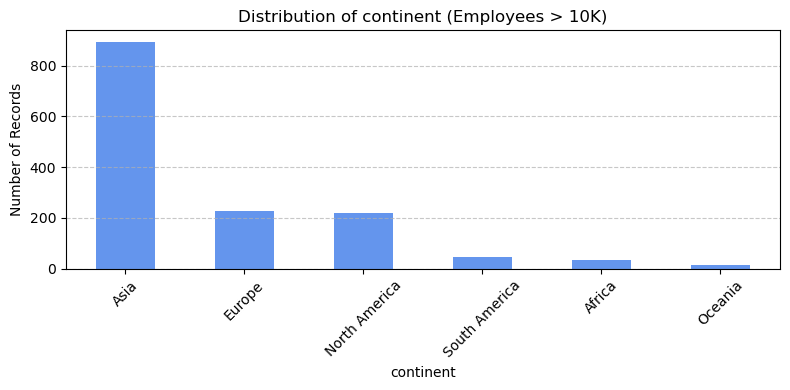

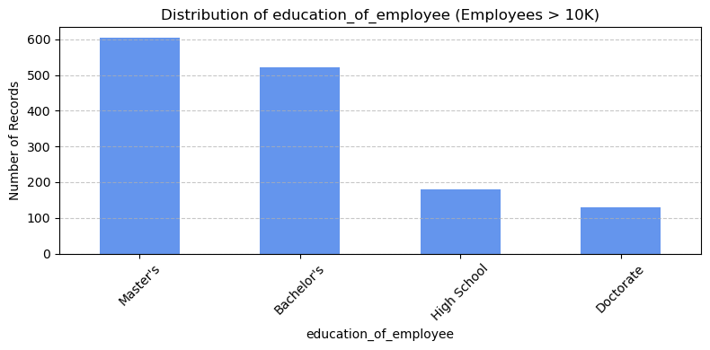

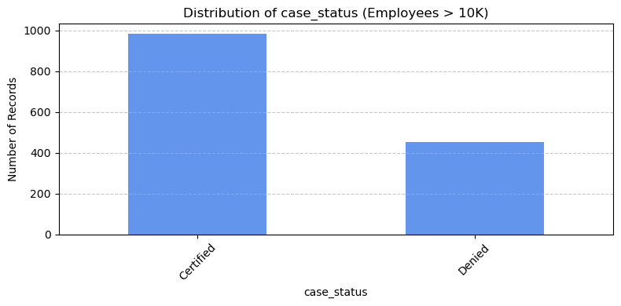

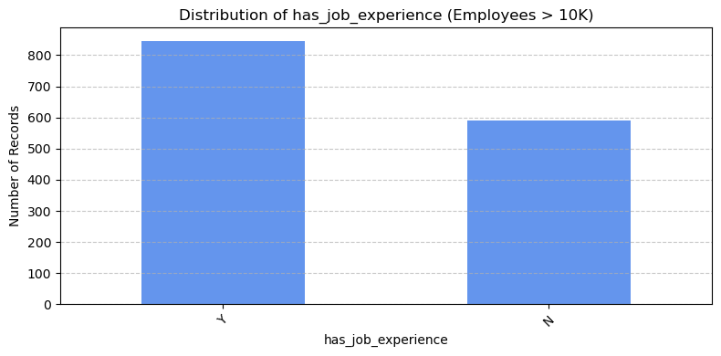

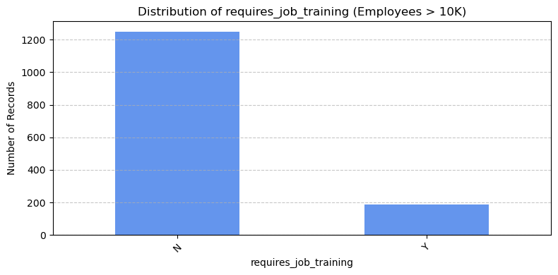

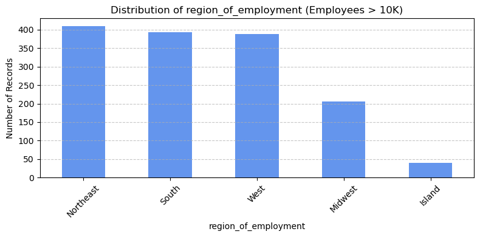

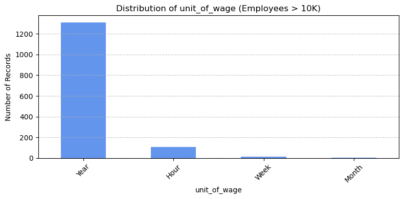

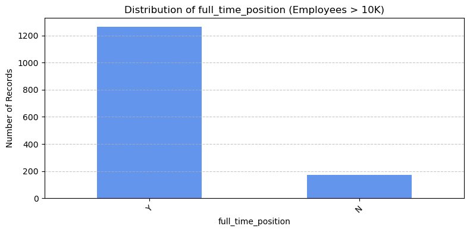

```python
large_companies = df[df['no_of_employees'] > 10_000]

features_to_plot = [
    'continent',
    'education_of_employee',
    'case_status',
    'has_job_experience',
    'requires_job_training',
    'region_of_employment',
    'unit_of_wage',
    'full_time_position'
]

for feature in features_to_plot:
    plt.figure(figsize=(8, 4))
    large_companies[feature].value_counts(dropna=False).plot(kind='bar', color='cornflowerblue')
    plt.title(f'Distribution of {feature} (Employees > 10K)')
    plt.xlabel(feature)
    plt.ylabel('Number of Records')
    plt.xticks(rotation=45)
    plt.tight_layout()
    plt.grid(axis='y', linestyle='--', alpha=0.7)
    plt.show()
```

```python
df.drop(["employee_bin"], axis=1, inplace=True)
```

### Are visa approval rates different across various continents of employees? Which continent has the highest and lowest approval rates?

```
case_status    Certified  Denied    All
continent
All                17001    8446  25447
Asia               11001    5839  16840
North America       2037    1250   3287
Europe              2953     774   3727
South America        492     359    851
Africa               396     154    550
Oceania              122      70    192
------------------------------------------------------------------------------------------------------------------------
```

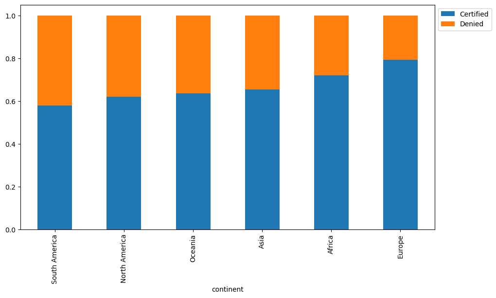

```python
stacked_barplot(df, "continent", "case_status")
```

**Europe** has the **highest visa approval rate (~79%)**, suggesting strong applicant profiles or favorable processing trends.

# **Data Pre-processing**

- Missing value treatment (if needed)
- Feature engineering (if needed)
- Outlier detection and treatment (if needed)
- Preparing data for modeling
- Any other preprocessing steps (if needed)

#### Missing value treatment (if needed)

```python
df.isnull().sum()
```

```
continent                0
education_of_employee    0
has_job_experience       0
requires_job_training    0
no_of_employees          0
yr_of_estab              0
region_of_employment     0
prevailing_wage          0
unit_of_wage             0
full_time_position       0
case_status              0
dtype: int64
```

#### Outlier detection and treatment

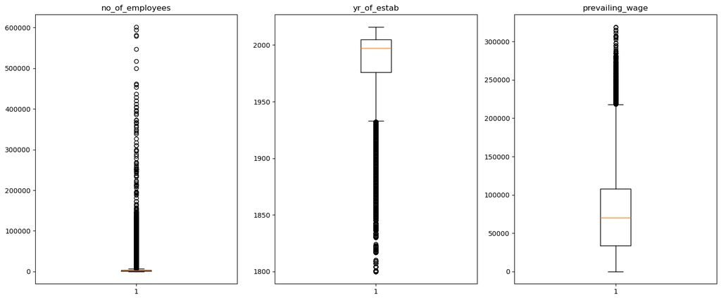

```python
numerical_col = df.select_dtypes(include=np.number).columns.tolist()
plt.figure(figsize=(20, 30))

for i, variable in enumerate(numerical_col):
    plt.subplot(5, 4, i + 1)
    plt.boxplot(df[variable], whis=1.5)
    plt.tight_layout()
    plt.title(variable)

plt.show()
```

### Feature engineering

```python
df.shape
```

```
(25447, 11)
```

```python
# 1. Remove invalid values: zero or negative employee counts
df = df[df['no_of_employees'] > 0].copy()

# 2. Cap extreme values to reduce skew (capping at 100,000)
df['no_of_employees_capped'] = np.clip(df['no_of_employees'], a_min=1, a_max=100_000)

# 3. Log-transform the employee count (good for skewed features)
df['log_employees'] = np.log1p(df['no_of_employees_capped'])  # log(1 + x)

# 4. Bin employee counts into interpretable categorical ranges
bins = list(range(0, 11_000, 1000)) + [25_000, 50_000, 100_000, np.inf]
labels = [
    '0–1k', '1k–2k', '2k–3k', '3k–4k', '4k–5k', '5k–6k', '6k–7k', '7k–8k', '8k–9k', '9k–10k',
    '10k–25k', '25k–50k', '50k–100k', '100k+'
]
df['employee_bin'] = pd.cut(df['no_of_employees_capped'], bins=bins, labels=labels, right=False)
```

```python
df.shape
```

```
(25447, 14)
```

```python
df.head()
```

|  | continent | education_of_employee | has_job_experience | requires_job_training | no_of_employees | yr_of_estab | region_of_employment | prevailing_wage | unit_of_wage | full_time_position | case_status | no_of_employees_capped | log_employees | employee_bin |
| --- | --- | --- | --- | --- | --- | --- | --- | --- | --- | --- | --- | --- | --- | --- |
| 0 | Asia | High School | N | N | 14513 | 2007 | West | 592.2029 | Hour | Y | Denied | 14513 | 9.582869 | 10k–25k |
| 1 | Asia | Master's | Y | N | 2412 | 2002 | Northeast | 83425.6500 | Year | Y | Certified | 2412 | 7.788626 | 2k–3k |
| 2 | Asia | Bachelor's | N | Y | 44444 | 2008 | West | 122996.8600 | Year | Y | Denied | 44444 | 10.702008 | 25k–50k |
| 3 | Asia | Bachelor's | N | N | 98 | 1897 | West | 83434.0300 | Year | Y | Denied | 98 | 4.595120 | 0–1k |
| 4 | Africa | Master's | Y | N | 1082 | 2005 | South | 149907.3900 | Year | Y | Certified | 1082 | 6.987490 | 1k–2k |

```python
df['log_wage'] = np.log1p(df['prevailing_wage'])
```

```python
df['company_age'] = 2025 - df['yr_of_estab']
```

```python
df.shape
```

```
(25447, 16)
```

```python
df.head()
```

|  | continent | education_of_employee | has_job_experience | requires_job_training | no_of_employees | yr_of_estab | region_of_employment | prevailing_wage | unit_of_wage | full_time_position | case_status | no_of_employees_capped | log_employees | employee_bin | log_wage | company_age |
| --- | --- | --- | --- | --- | --- | --- | --- | --- | --- | --- | --- | --- | --- | --- | --- | --- |
| 0 | Asia | High School | N | N | 14513 | 2007 | West | 592.2029 | Hour | Y | Denied | 14513 | 9.582869 | 10k–25k | 6.385536 | 18 |
| 1 | Asia | Master's | Y | N | 2412 | 2002 | Northeast | 83425.6500 | Year | Y | Certified | 2412 | 7.788626 | 2k–3k | 11.331723 | 23 |
| 2 | Asia | Bachelor's | N | Y | 44444 | 2008 | West | 122996.8600 | Year | Y | Denied | 44444 | 10.702008 | 25k–50k | 11.719922 | 17 |
| 3 | Asia | Bachelor's | N | N | 98 | 1897 | West | 83434.0300 | Year | Y | Denied | 98 | 4.595120 | 0–1k | 11.331824 | 128 |
| 4 | Africa | Master's | Y | N | 1082 | 2005 | South | 149907.3900 | Year | Y | Certified | 1082 | 6.987490 | 1k–2k | 11.917780 | 20 |

```python
# Make a copy of the dataset
data1 = df.copy()
```

### Preparing data for modeling

```python
data1.drop(["yr_of_estab"], axis=1, inplace=True)
data1['case_status'] = data1['case_status'].map({'Denied': 0, 'Certified': 1})  # Convert target to binary
```

```python
# Step 1: Split into features and target
X = data1.drop(columns='case_status')
y = data1['case_status']

# Step 2: Split into train/val/test sets (60/20/20)
from sklearn.model_selection import train_test_split

X_temp, X_test, y_temp, y_test = train_test_split(
    X, y, test_size=0.2, stratify=y, random_state=1
)

X_train, X_val, y_train, y_val = train_test_split(
    X_temp, y_temp, test_size=0.25, stratify=y_temp, random_state=1
)

# Step 3: Identify categorical columns from training set
categorical_cols = X_train.select_dtypes(include=['object', 'category']).columns.tolist()

# Step 4: One-hot encode training set
X_train = pd.get_dummies(X_train, columns=categorical_cols, drop_first=True)

# Step 5: Encode validation and test sets using training columns
X_val = pd.get_dummies(X_val, columns=categorical_cols, drop_first=True)
X_val = X_val.reindex(columns=X_train.columns, fill_value=0)

X_test = pd.get_dummies(X_test, columns=categorical_cols, drop_first=True)
X_test = X_test.reindex(columns=X_train.columns, fill_value=0)

# Step 6: Check shapes
print("Train shape:", X_train.shape)
print("Validation shape:", X_val.shape)
print("Test shape:", X_test.shape)
```

```
Train shape: (15267, 37)
Validation shape: (5090, 37)
Test shape: (5090, 37)
```

```python
X_train.head()
```

|  | no_of_employees | prevailing_wage | no_of_employees_capped | log_employees | log_wage | company_age | continent_Asia | continent_Europe | continent_North America | continent_Oceania | continent_South America | education_of_employee_Doctorate | education_of_employee_High School | education_of_employee_Master's | has_job_experience_Y | requires_job_training_Y | region_of_employment_Midwest | region_of_employment_Northeast | region_of_employment_South | region_of_employment_West | unit_of_wage_Month | unit_of_wage_Week | unit_of_wage_Year | full_time_position_Y | employee_bin_1k–2k | employee_bin_2k–3k | employee_bin_3k–4k | employee_bin_4k–5k | employee_bin_5k–6k | … |
| --- | --- | --- | --- | --- | --- | --- | --- | --- | --- | --- | --- | --- | --- | --- | --- | --- | --- | --- | --- | --- | --- | --- | --- | --- | --- | --- | --- | --- | --- | --- |
| 13421 | 2711 | 86707.20 | 2711 | 7.905442 | 11.370304 | 22 | True | False | False | False | False | False | False | True | False | False | False | False | False | True | False | False | True | True | False | True | False | False | False | … |
| 7213 | 4515 | 20136.52 | 4515 | 8.415382 | 9.910340 | 55 | True | False | False | False | False | False | False | False | True | False | False | False | False | True | False | False | True | True | False | False | False | True | False | … |
| 5833 | 2804 | 61488.43 | 2804 | 7.939159 | 11.026621 | 186 | False | True | False | False | False | False | True | False | True | False | False | False | False | True | False | False | True | True | False | True | False | False | False | … |
| 4404 | 4298 | 50834.53 | 4298 | 8.366138 | 10.836351 | 32 | True | False | False | False | False | False | False | True | False | False | False | True | False | False | False | False | True | True | False | False | False | True | False | … |
| 1041 | 962 | 25041.81 | 962 | 6.870053 | 10.128342 | 153 | True | False | False | False | False | False | False | True | True | False | False | False | True | False | False | False | True | True | False | False | False | False | False | … |

```python
X_train = X_train.astype(int)
X_val = X_val.astype(int)
X_test = X_test.astype(int)
```

```python
X_train.head()
```

|  | no_of_employees | prevailing_wage | no_of_employees_capped | log_employees | log_wage | company_age | continent_Asia | continent_Europe | continent_North America | continent_Oceania | continent_South America | education_of_employee_Doctorate | education_of_employee_High School | education_of_employee_Master's | has_job_experience_Y | requires_job_training_Y | region_of_employment_Midwest | region_of_employment_Northeast | region_of_employment_South | region_of_employment_West | unit_of_wage_Month | unit_of_wage_Week | unit_of_wage_Year | full_time_position_Y | employee_bin_1k–2k | employee_bin_2k–3k | employee_bin_3k–4k | employee_bin_4k–5k | employee_bin_5k–6k | … |
| --- | --- | --- | --- | --- | --- | --- | --- | --- | --- | --- | --- | --- | --- | --- | --- | --- | --- | --- | --- | --- | --- | --- | --- | --- | --- | --- | --- | --- | --- | --- |
| 13421 | 2711 | 86707 | 2711 | 7 | 11 | 22 | 1 | 0 | 0 | 0 | 0 | 0 | 0 | 1 | 0 | 0 | 0 | 0 | 0 | 1 | 0 | 0 | 1 | 1 | 0 | 1 | 0 | 0 | 0 | … |
| 7213 | 4515 | 20136 | 4515 | 8 | 9 | 55 | 1 | 0 | 0 | 0 | 0 | 0 | 0 | 0 | 1 | 0 | 0 | 0 | 0 | 1 | 0 | 0 | 1 | 1 | 0 | 0 | 0 | 1 | 0 | … |
| 5833 | 2804 | 61488 | 2804 | 7 | 11 | 186 | 0 | 1 | 0 | 0 | 0 | 0 | 1 | 0 | 1 | 0 | 0 | 0 | 0 | 1 | 0 | 0 | 1 | 1 | 0 | 1 | 0 | 0 | 0 | … |
| 4404 | 4298 | 50834 | 4298 | 8 | 10 | 32 | 1 | 0 | 0 | 0 | 0 | 0 | 0 | 1 | 0 | 0 | 0 | 1 | 0 | 0 | 0 | 0 | 1 | 1 | 0 | 0 | 0 | 1 | 0 | … |
| 1041 | 962 | 25041 | 962 | 6 | 10 | 153 | 1 | 0 | 0 | 0 | 0 | 0 | 0 | 1 | 1 | 0 | 0 | 0 | 1 | 0 | 0 | 0 | 1 | 1 | 0 | 0 | 0 | 0 | 0 | … |

```python
X_train.shape
```

```
(15267, 37)
```

# **Model Building**

## Model evaluation criterion

**Model can make wrong predictions as**:

1. Model predicts that the visa application will get certified but in reality, the visa application should get denied.
2. Model predicts that the visa application will not get certified but in reality, the visa application should get certified.

**Which case is more important?**

- Both the cases are important as:
- If a visa is certified when it had to be denied a wrong employee will get the job position while US citizens will miss the opportunity to work on that position.
- If a visa is denied when it had to be certified the U.S. will lose a suitable human resource that can contribute to the economy.

**How to reduce the losses?**

- `F1 Score` can be used a the metric for evaluation of the model, greater the F1 score higher are the chances of minimizing False Negatives and False Positives.
- We will use balanced class weights so that model focuses equally on both classes.

```python
# defining a function to compute different metrics to check performance of a classification model built using sklearn
def model_performance_classification_sklearn(model, predictors, target):
    """
    Function to compute different metrics to check classification model performance

    model: classifier
    predictors: independent variables
    target: dependent variable
    """

    # predicting using the independent variables
    pred = model.predict(predictors)

    acc = accuracy_score(target, pred)  # to compute Accuracy
    recall = recall_score(target, pred)  # to compute Recall
    precision = precision_score(target, pred)  # to compute Precision
    f1 = f1_score(target, pred)  # to compute F1-score

    # creating a dataframe of metrics
    df_perf = pd.DataFrame(
        {"Accuracy": acc, "Recall": recall, "Precision": precision, "F1": f1,},
        index=[0],
    )

    return df_perf
```

```python
def confusion_matrix_sklearn(model, predictors, target):
    """
    To plot the confusion_matrix with percentages

    model: classifier
    predictors: independent variables
    target: dependent variable
    """
    y_pred = model.predict(predictors)
    cm = confusion_matrix(target, y_pred)
    labels = np.asarray(
        [
            ["{0:0.0f}".format(item) + "\n{0:.2%}".format(item / cm.flatten().sum())]
            for item in cm.flatten()
        ]
    ).reshape(2, 2)

    plt.figure(figsize=(6, 4))
    sns.heatmap(cm, annot=labels, fmt="")
    plt.ylabel("True label")
    plt.xlabel("Predicted label")
```

## Initial Model Building

### Model Building - Original Data

### Intro to KFold Cross Validation:

1. **Definition**:
- K-Fold Cross-Validation is a resampling technique used to evaluate the performance of a machine learning model. It splits the dataset into K subsets (folds), trains the model on K-1 folds, and tests it on the remaining fold. This process is repeated K times, with each fold used as the test set exactly once. The final performance is the average of the evaluation metric (e.g., accuracy, recall, etc.) across all folds.
2. **Why We Use K-Fold Cross-Validation:**
- Robust Performance Estimation: It provides a better estimate of a model’s performance by using all data points for both training and testing (but not at the same time).
- Reduces Overfitting: Unlike a single train-test split, K-Fold Cross-Validation ensures the model is tested on multiple unseen subsets of data, reducing the chance of overfitting to a specific dataset split.
- Maximizes Data Usage: It uses all data for training and testing at different stages, making it ideal for small datasets where splitting once may not be sufficient.
4. **Analogy 1:**
- Context: Imagine you're preparing for a big exam. Instead of solving one full-length practice test, you divide the syllabus into K topics. Each time, you study K-1 topics and take a mini-test on the remaining topic. You repeat this process until you've tested yourself on every topic. Finally, you average your scores across all tests to determine how well-prepared you are.
- K topics = K folds.
- Studying K-1 topics = Training the model on K-1 folds.
- Testing on the remaining topic = Testing the model on the remaining fold.
- By the end of this process, you have a clear idea of your strengths and weaknesses across the entire syllabus, just like K-Fold Cross-Validation gives a clear picture of the model's performance across the dataset.
5. **Analogy 2:**
- Context: Sports Team Practice. Imagine you're coaching a sports team, and you want to prepare them for a big game. Instead of having everyone practice together all the time, you divide the team into K groups and follow this process:
- You let K-1 groups practice together (this is your training phase).
- The remaining group plays a practice match against the others to test their skills (this is your testing phase).
- Rotate the groups, so each group gets a chance to be the test group once.
- By the end, every group has been tested, and you've identified strengths and weaknesses across the entire team.
6. **Key Takeaways:**
- K-Fold Cross-Validation ensures the model is rigorously tested on all parts of the data.
- It prevents biased evaluations and increases confidence in a model's ability to generalize.

```python
from sklearn.model_selection import StratifiedKFold, cross_val_score
from sklearn.metrics import make_scorer, f1_score

# Define F1 scorer
f1_scorer = make_scorer(f1_score)

# List of models to evaluate
models = [
    ("Bagging", BaggingClassifier(random_state=1)),
    ("Random forest", RandomForestClassifier(random_state=1)),
    ("GBM", GradientBoostingClassifier(random_state=1)),
    ("Adaboost", AdaBoostClassifier(random_state=1)),
    ("DTree", DecisionTreeClassifier(random_state=1)),
    ("LGBM", LGBMClassifier(random_state=1, verbose=-1)),
    ("CatBoost", CatBoostClassifier(random_state=1, verbose=0)),
]

# === Cross-Validation on Training Set ===
print("\nCross-Validation performance on training dataset (F1-score):\n")

for name, model in models:
    kfold = StratifiedKFold(n_splits=5, shuffle=True, random_state=1)
    f1_cv = cross_val_score(model, X_train, y_train, scoring=f1_scorer, cv=kfold)
    print(f"{name}: F1 = {f1_cv.mean():.4f}")

# === Evaluation on Validation Set ===
print("\nValidation Performance (F1-score):\n")

for name, model in models:
    model.fit(X_train, y_train)
    y_pred_val = model.predict(X_val)
    val_f1 = f1_score(y_val, y_pred_val)
    print(f"{name}: F1 = {val_f1:.4f}")
```

```
Cross-Validation performance on training dataset (F1-score):

Bagging: F1 = 0.7689
Random forest: F1 = 0.8028
GBM: F1 = 0.8225
Adaboost: F1 = 0.8149
DTree: F1 = 0.7462
LGBM: F1 = 0.8185
CatBoost: F1 = 0.8185

Validation Performance (F1-score):

Bagging: F1 = 0.7815
Random forest: F1 = 0.8015
GBM: F1 = 0.8261
Adaboost: F1 = 0.8196
DTree: F1 = 0.7449
LGBM: F1 = 0.8202
CatBoost: F1 = 0.8190
```

```python
print("\nTraining and Validation Performance Difference:\n")

for name, model in models:
    model.fit(X_train, y_train)
    scores_train = f1_score(y_train, model.predict(X_train))
    scores_val = f1_score(y_val, model.predict(X_val))
    difference1 = scores_train - scores_val
    print("{}: Training Score: {:.4f}, Validation Score: {:.4f}, Difference: {:.4f}".format(name, scores_train, scores_val, difference1))
```

```
Training and Validation Performance Difference:

Bagging: Training Score: 0.9886, Validation Score: 0.7815, Difference: 0.2072
Random forest: Training Score: 1.0000, Validation Score: 0.8015, Difference: 0.1985
GBM: Training Score: 0.8276, Validation Score: 0.8261, Difference: 0.0015
Adaboost: Training Score: 0.8192, Validation Score: 0.8196, Difference: -0.0004
DTree: Training Score: 1.0000, Validation Score: 0.7449, Difference: 0.2551
LGBM: Training Score: 0.8453, Validation Score: 0.8202, Difference: 0.0251
CatBoost: Training Score: 0.8545, Validation Score: 0.8190, Difference: 0.0356
```

- GBM has the best performance (0.8261)

### Model Building - Oversampled Data

## Oversampling in Machine Learning

### **Definition**

Oversampling is a technique used in machine learning to address class imbalance in classification problems. It involves increasing the number of instances in the minority class by duplicating existing samples or generating synthetic samples, so that both classes are better represented in the dataset.

### **Why We Use Oversampling**

In imbalanced datasets, machine learning models tend to be biased toward the majority class. This can lead to poor performance when predicting the minority class, especially in metrics like recall, precision, or F1-score. Oversampling helps correct this bias.

### **What It Is Used For**

- **Binary classification** problems with a significant class imbalance (e.g., fraud detection, disease diagnosis)
- **Multiclass problems** where one or more classes are underrepresented
- When improving the model's **ability to detect rare events** is more important than overall accuracy

### **How It’s Helpful**

- Improves model **generalization** to the minority class
- Increases **recall** and **F1-score** for minority classes
- Reduces the likelihood that the model will ignore rare but important classes
- Helps in **training stable models** with more balanced decision boundaries

### **Common Oversampling Techniques**

- **Random Oversampling:** Simply duplicates random samples from the minority class.
- **SMOTE (Synthetic Minority Over-sampling Technique):** Generates new, synthetic examples by interpolating between existing minority class instances.
- **ADASYN:** An extension of SMOTE that focuses on difficult-to-learn examples.

### **What Is SMOTE?**

SMOTE (Synthetic Minority Over-sampling Technique) is one of the most widely used oversampling methods. Instead of duplicating existing samples, SMOTE creates new synthetic data points by selecting a sample from the minority class and introducing new samples along the line segments joining that sample and its k-nearest minority class neighbors. This process increases the diversity of the minority class and helps the model learn a more general decision boundary. SMOTE is especially useful because it avoids the risk of overfitting that often occurs with simple duplication, and it helps balance the dataset in a more realistic way by enriching the feature space with new, interpolated examples.

### **How Are Synthetic Samples Not Fake?**

Synthetic samples are not "fake" in the sense of being random or unrelated to the actual data. Instead, they are systematically generated from real data points using mathematical interpolation. For example, SMOTE creates new points by calculating values that lie between existing minority class samples in the feature space. These new samples preserve the structure, distribution, and relationships present in the real data, allowing the model to learn patterns more effectively. While synthetic, they are grounded in actual data and represent plausible variations that the model could encounter in the real world.

```python
print("Before Oversampling, counts of label 'Yes': {}".format(sum(y_train == 1)))
print("Before Oversampling, counts of label 'No': {} \n".format(sum(y_train == 0)))

# Purpose:
# This code applies SMOTE (Synthetic Minority Over-sampling Technique) to address class imbalance
# by generating synthetic samples for the minority class. It does so by interpolating between existing
# minority class samples and their nearest neighbors.

from imblearn.over_sampling import SMOTE

# 1. Define your oversampling technique:
sm = SMOTE(
    sampling_strategy=1,     # Balance the classes so that minority and majority have equal numbers (1:1 ratio)
    k_neighbors=5,           # For each minority sample, SMOTE selects 5 nearest neighbors from the same class
    random_state=1           # Seed for reproducibility
)  # Synthetic Minority Over-sampling Technique

# Apply SMOTE to the training data only (never apply to validation or test sets)
X_train_over, y_train_over = sm.fit_resample(X_train, y_train)

# What is k_neighbors=5?
# For each minority class instance, SMOTE finds its 5 nearest neighbors using Euclidean distance.
# Then, it randomly selects one of those 5 neighbors and creates a synthetic sample along the line
# connecting the original point and the neighbor. This process is repeated until the desired class
# balance is achieved. k_neighbors=5 is the default and a common choice to ensure diversity in synthetic samples.

print("After Oversampling, counts of label 'Yes': {}".format(sum(y_train_over == 1)))
print("After Oversampling, counts of label 'No': {} \n".format(sum(y_train_over == 0)))


print("After Oversampling, the shape of train_X: {}".format(X_train_over.shape))
print("After Oversampling, the shape of train_y: {} \n".format(y_train_over.shape))
```

```
Before Oversampling, counts of label 'Yes': 10199
Before Oversampling, counts of label 'No': 5068

After Oversampling, counts of label 'Yes': 10199
After Oversampling, counts of label 'No': 10199

After Oversampling, the shape of train_X: (20398, 37)
After Oversampling, the shape of train_y: (20398,)
```

```python
# Initialize the list of models
models = []  # Empty list to store all the models

# Append models to the list
models.append(("Bagging", BaggingClassifier(
    estimator=DecisionTreeClassifier(random_state=1, class_weight='balanced'), random_state=1)))
models.append(("Random forest", RandomForestClassifier(random_state=1, class_weight='balanced')))
models.append(("GBM", GradientBoostingClassifier(random_state=1)))
models.append(("Adaboost", AdaBoostClassifier(random_state=1)))
models.append(("dtree", DecisionTreeClassifier(random_state=1, class_weight='balanced')))
models.append(("LGBM", LGBMClassifier(random_state=1, verbose=-1)))  # LightGBM
models.append(("CatBoost", CatBoostClassifier(random_state=1, verbose=0)))  # CatBoost

# Evaluate training performance using F1-score
print("\nTraining Performance (F1-score):\n")
for name, model in models:
    model.fit(X_train_over, y_train_over)
    scores = f1_score(y_train_over, model.predict(X_train_over))
    print(f"{name}: {scores:.4f}")

# Evaluate validation performance using F1-score
print("\nValidation Performance (F1-score):\n")
for name, model in models:
    model.fit(X_train_over, y_train_over)
    scores = f1_score(y_val, model.predict(X_val))
    print(f"{name}: {scores:.4f}")
```

```
Training Performance (F1-score):

Bagging: 0.9866
Random forest: 1.0000
GBM: 0.8051
Adaboost: 0.7793
dtree: 1.0000
LGBM: 0.8264
CatBoost: 0.8443

Validation Performance (F1-score):

Bagging: 0.7656
Random forest: 0.7929
GBM: 0.8075
Adaboost: 0.7866
dtree: 0.7326
LGBM: 0.8092
CatBoost: 0.8090
```

```python
print("\nTraining and Validation Performance Difference (F1-score):\n")

for name, model in models:
    model.fit(X_train_over, y_train_over)
    scores_train = f1_score(y_train_over, model.predict(X_train_over))
    scores_val = f1_score(y_val, model.predict(X_val))
    difference = scores_train - scores_val
    print(f"{name}: Training Score: {scores_train:.4f}, Validation Score: {scores_val:.4f}, Difference: {difference:.4f}")
```

```
Training and Validation Performance Difference (F1-score):

Bagging: Training Score: 0.9866, Validation Score: 0.7656, Difference: 0.2211
Random forest: Training Score: 1.0000, Validation Score: 0.7929, Difference: 0.2071
GBM: Training Score: 0.8051, Validation Score: 0.8075, Difference: -0.0024
Adaboost: Training Score: 0.7793, Validation Score: 0.7866, Difference: -0.0072
dtree: Training Score: 1.0000, Validation Score: 0.7326, Difference: 0.2674
LGBM: Training Score: 0.8264, Validation Score: 0.8092, Difference: 0.0172
CatBoost: Training Score: 0.8443, Validation Score: 0.8090, Difference: 0.0353
```

LGBM has the best performance on validation

### Model Building - Undersampled Data

## Undersampling in Machine Learning

### **Definition**

Undersampling is a technique used to handle class imbalance in machine learning by reducing the number of samples in the majority class. This is done to create a more balanced dataset, which can help the model learn to recognize patterns in both classes more fairly.

### **Why We Use Undersampling**

In highly imbalanced datasets, models tend to favor the majority class, often misclassifying minority class examples. Undersampling reduces this bias by balancing the class distribution, allowing the model to pay more attention to the minority class. It’s particularly useful when the dataset is large and computational efficiency is a concern.

### **What It Is Used For**

- **Binary classification** problems where the majority class overwhelms the minority class (e.g., spam detection, credit default)
- When we have a **large dataset** and want to reduce training time
- When preserving all majority class data is not critical, and some loss of information is acceptable

### **How It’s Helpful**

- Helps the model **focus equally** on both classes
- Reduces **training time** and **computational cost** by trimming the dataset size
- Improves **recall and precision** for the minority class in some cases
- Avoids **overfitting** to the majority class

### **Common Undersampling Techniques**

- **Random Undersampling:** Randomly removes samples from the majority class.
- **Tomek Links:** Identifies and removes borderline majority class instances that are close to minority class examples.
- **NearMiss:** Selects majority class samples that are closest to minority class instances, keeping only the most informative ones.

### **What Is RandomUnderSampler?**

RandomUnderSampler is a basic and widely used undersampling technique provided by libraries such as `imbalanced-learn`. It works by randomly selecting a subset of the majority class so that it matches the size of the minority class. This straightforward approach is efficient and easy to apply, especially when the dataset is large and can afford to lose some examples. Although it may discard potentially useful data, RandomUnderSampler is useful when training speed is important or when models are severely overfitting due to class imbalance. It is often used as a baseline before trying more advanced undersampling techniques.

### **How Is Reduced Data Still Useful?**

Even though undersampling removes some data, the remaining majority class samples are often sufficient for the model to learn general patterns, especially when the dataset is initially large. The key idea is that **reducing quantity does not necessarily mean losing quality**—the algorithm still sees enough diversity in the majority class to build accurate decision boundaries. Additionally, careful selection techniques like NearMiss ensure that only the most informative samples are retained, making the reduced dataset both smaller and more efficient for learning.

```python
rus = RandomUnderSampler(random_state=1)
X_train_un, y_train_un = rus.fit_resample(X_train, y_train)
```

```python
print("Before Under Sampling, counts of label 'Yes': {}".format(sum(y_train == 1)))
print("Before Under Sampling, counts of label 'No': {} \n".format(sum(y_train == 0)))

print("After Under Sampling, counts of label 'Yes': {}".format(sum(y_train_un == 1)))
print("After Under Sampling, counts of label 'No': {} \n".format(sum(y_train_un == 0)))

print("After Under Sampling, the shape of train_X: {}".format(X_train_un.shape))
print("After Under Sampling, the shape of train_y: {} \n".format(y_train_un.shape))
```

```
Before Under Sampling, counts of label 'Yes': 10199
Before Under Sampling, counts of label 'No': 5068

After Under Sampling, counts of label 'Yes': 5068
After Under Sampling, counts of label 'No': 5068

After Under Sampling, the shape of train_X: (10136, 37)
After Under Sampling, the shape of train_y: (10136,)
```

```python
models = []  # List to store all classifiers

# Append models
models.append(("Bagging", BaggingClassifier(estimator=DecisionTreeClassifier(random_state=1, class_weight='balanced'), random_state=1)))
models.append(("Random forest", RandomForestClassifier(random_state=1, class_weight='balanced')))
models.append(("GBM", GradientBoostingClassifier(random_state=1)))
models.append(("Adaboost", AdaBoostClassifier(random_state=1)))
models.append(("dtree", DecisionTreeClassifier(random_state=1, class_weight='balanced')))
models.append(("LGBM", LGBMClassifier(random_state=1, verbose=-1)))
models.append(("CatBoost", CatBoostClassifier(random_state=1, verbose=0)))

print("\nTraining Performance (F1-score):\n")
for name, model in models:
    model.fit(X_train_un, y_train_un)
    score_train = f1_score(y_train_un, model.predict(X_train_un))
    print(f"{name}: {score_train:.4f}")

print("\nValidation Performance (F1-score):\n")
for name, model in models:
    model.fit(X_train_un, y_train_un)
    score_val = f1_score(y_val, model.predict(X_val))
    print(f"{name}: {score_val:.4f}")
```

```
Training Performance (F1-score):

Bagging: 0.9808
Random forest: 1.0000
GBM: 0.7289
Adaboost: 0.7037
dtree: 1.0000
LGBM: 0.7802
CatBoost: 0.7869

Validation Performance (F1-score):

Bagging: 0.7022
Random forest: 0.7363
GBM: 0.7693
Adaboost: 0.7646
dtree: 0.6937
LGBM: 0.7621
CatBoost: 0.7615
```

```python
print("\nTraining and Validation Performance Difference (F1-score):\n")

for name, model in models:
    model.fit(X_train_un, y_train_un)
    scores_train = f1_score(y_train_un, model.predict(X_train_un))
    scores_val = f1_score(y_val, model.predict(X_val))
    difference = scores_train - scores_val
    print(f"{name}: Training Score: {scores_train:.4f}, Validation Score: {scores_val:.4f}, Difference: {difference:.4f}")
```

```
Training and Validation Performance Difference (F1-score):

Bagging: Training Score: 0.9808, Validation Score: 0.7022, Difference: 0.2787
Random forest: Training Score: 1.0000, Validation Score: 0.7363, Difference: 0.2637
GBM: Training Score: 0.7289, Validation Score: 0.7693, Difference: -0.0404
Adaboost: Training Score: 0.7037, Validation Score: 0.7646, Difference: -0.0610
dtree: Training Score: 1.0000, Validation Score: 0.6937, Difference: 0.3063
LGBM: Training Score: 0.7802, Validation Score: 0.7621, Difference: 0.0182
CatBoost: Training Score: 0.7869, Validation Score: 0.7615, Difference: 0.0253
```

- GBM has the best performance
- After building 21 models, it was observed that both the GBM, Catboost and Adaboost models, trained on an undersampled dataset, as well as the GBM model trained on an oversampled dataset, exhibited strong performance on both the training and validation datasets.
- Sometimes models might overfit after undersampling and oversampling, so it's better to tune the models to get a generalized performance
- We will tune these 3 models using the same data (undersampled or oversampled) as we trained them on before

## Hyperparameter Tuning

| **Criteria** | **GridSearchCV** | **RandomizedSearchCV** |
| --- | --- | --- |
| **Search Method** | Exhaustive search over specified parameter values. | Random search over a specified parameter distribution. |
| **Parameter Space** | Evaluates all possible combinations of parameters. | Evaluates a fixed number of random parameter combinations. |
| **Execution Time** | Generally longer due to exhaustive search, especially with large parameter spaces. | Generally shorter because it evaluates fewer combinations. |
| **Computational Cost** | Higher, because it evaluates all combinations. | Lower, because it evaluates a subset of combinations. |
| **Likelihood of Finding Optimal Parameters** | Higher if the parameter space is small, because all combinations are tested. | Depends on the number of iterations and the randomness of sampling; good for large parameter spaces. |
| **Use Case Suitability** | Best for small to medium-sized parameter grids where exhaustive search is feasible. | Best for large parameter grids where exhaustive search is impractical. |
| **Control Over Search** | Full control over the parameter combinations to be tested. | Less control; relies on random sampling. |
| **Scalability** | Less scalable with an increasing number of parameters or parameter values. | More scalable with an increasing number of parameters or parameter values. |
| **Implementation Simplicity** | Simple but potentially requires more computing resources. | More complex but can be more efficient in terms of resource usage. |
| **Parallel Processing** | Supports parallel processing to speed up the search. | Supports parallel processing to speed up the search. |

### Tuning AdaBoostClassifier model with original data

```python
%%time
# 1. Defining model
Model = AdaBoostClassifier(random_state=1)


param_grid = {
    "n_estimators": np.arange(50,110,25),
    "learning_rate": [0.01,0.1,0.05],
    "estimator": [
        DecisionTreeClassifier(max_depth=2, random_state=1),
        DecisionTreeClassifier(max_depth=3, random_state=1),
    ],
}

# 3. Type of scoring used to compare parameter combinations
scorer = metrics.make_scorer(metrics.f1_score)

#5. Calling RandomizedSearchCV
randomized_cv = RandomizedSearchCV(estimator=Model, param_distributions=param_grid, n_jobs = -1, n_iter=50, scoring=scorer,
                             cv=5, # will do cross validation for u automatically
                             random_state=1)

#Fitting parameters in RandomizedSearchCV
randomized_cv.fit(X_train, y_train)

print("Best parameters are {} with CV score={}:" .format(randomized_cv.best_params_,randomized_cv.best_score_))
```

```
Best parameters are {'n_estimators': 75, 'learning_rate': 0.05, 'estimator': DecisionTreeClassifier(max_depth=3, random_state=1)} with CV score=0.8238154705996568:
CPU times: total: 4.77 s
Wall time: 1min 43s
```

```python
# Instantiate the tuned AdaBoost model with best parameters from RandomizedSearchCV
tuned_adb = AdaBoostClassifier(
    random_state=1,
    n_estimators=75,
    learning_rate=0.05,
    estimator=DecisionTreeClassifier(max_depth=3, random_state=1)  # Use base_estimator instead of estimator
)

# Fit the model to training data
tuned_adb.fit(X_train, y_train)
```

```
AdaBoostClassifier(estimator=DecisionTreeClassifier(max_depth=3,
                                                    random_state=1),
                   learning_rate=0.05, n_estimators=75, random_state=1)
```

### Checking model performance on training set

```python
# Checking model's performance on training set
adb_train = model_performance_classification_sklearn(tuned_adb, X_train, y_train)
adb_train
```

|  | Accuracy | Recall | Precision | F1 |
| --- | --- | --- | --- | --- |
| 0 | 0.74684 | 0.900775 | 0.76304 | 0.826206 |

### Checking model performance on validation set

```python
# Checking model's performance on validation set
adb_val = model_performance_classification_sklearn(tuned_adb, X_val, y_val)
adb_val
```

|  | Accuracy | Recall | Precision | F1 |
| --- | --- | --- | --- | --- |
| 0 | 0.744204 | 0.898853 | 0.761395 | 0.824434 |

### Tuning AdaBoostClassifier model with oversampling data

```python
%%time
# 1. Defining model
Model = AdaBoostClassifier(random_state=1)


param_grid = {
    "n_estimators": np.arange(50,110,25),
    "learning_rate": [0.01,0.1,0.05],
    "estimator": [
        DecisionTreeClassifier(max_depth=2, random_state=1),
        DecisionTreeClassifier(max_depth=3, random_state=1),
    ],
}

# 3. Type of scoring used to compare parameter combinations
scorer = metrics.make_scorer(metrics.f1_score)

#5. Calling RandomizedSearchCV
randomized_cv = RandomizedSearchCV(estimator=Model, param_distributions=param_grid, n_jobs = -1, n_iter=50, scoring=scorer,
                             cv=5, # will do cross validation for u automatically
                             random_state=1)

#Fitting parameters in RandomizedSearchCV
randomized_cv.fit(X_train_over, y_train_over)

print("Best parameters are {} with CV score={}:" .format(randomized_cv.best_params_,randomized_cv.best_score_))
```

```
Best parameters are {'n_estimators': 100, 'learning_rate': 0.1, 'estimator': DecisionTreeClassifier(max_depth=3, random_state=1)} with CV score=0.7961001835766475:
CPU times: total: 7.8 s
Wall time: 2min 21s
```

```python
# Instantiate the tuned AdaBoost model with best parameters from RandomizedSearchCV
tuned_adb_over = AdaBoostClassifier(
    random_state=1,
    n_estimators=100,
    learning_rate=0.1,
    estimator=DecisionTreeClassifier(max_depth=3, random_state=1)  # Use base_estimator instead of estimator
)

# Fit the model to training data
tuned_adb_over.fit(X_train_over, y_train_over)
```

```
AdaBoostClassifier(estimator=DecisionTreeClassifier(max_depth=3,
                                                    random_state=1),
                   learning_rate=0.1, n_estimators=100, random_state=1)
```

```python
# Checking model's performance on training set
adb_train_over = model_performance_classification_sklearn(tuned_adb_over, X_train_over, y_train_over)
adb_train_over
```

|  | Accuracy | Recall | Precision | F1 |
| --- | --- | --- | --- | --- |
| 0 | 0.79998 | 0.817629 | 0.789753 | 0.803449 |

### Checking model performance on validation set

```python
# Checking model's performance on validation set
adb_val_over = model_performance_classification_sklearn(tuned_adb_over, X_val, y_val)
adb_val_over
```

|  | Accuracy | Recall | Precision | F1 |
| --- | --- | --- | --- | --- |
| 0 | 0.734381 | 0.812702 | 0.794481 | 0.803488 |

### Tuning AdaBoostClassifier model with Undersampled data

```python
%%time
# 1. Defining model
Model = AdaBoostClassifier(random_state=1)


param_grid = {
    "n_estimators": np.arange(50,110,25),
    "learning_rate": [0.01,0.1,0.05],
    "estimator": [
        DecisionTreeClassifier(max_depth=2, random_state=1),
        DecisionTreeClassifier(max_depth=3, random_state=1),
    ],
}

# 3. Type of scoring used to compare parameter combinations
scorer = metrics.make_scorer(metrics.f1_score)

#5. Calling RandomizedSearchCV
randomized_cv = RandomizedSearchCV(estimator=Model, param_distributions=param_grid, n_jobs = -1, n_iter=50, scoring=scorer,
                             cv=5, # will do cross validation for u automatically
                             random_state=1)

#Fitting parameters in RandomizedSearchCV
randomized_cv.fit(X_train_un, y_train_un)

print("Best parameters are {} with CV score={}:" .format(randomized_cv.best_params_,randomized_cv.best_score_))
```

```
Best parameters are {'n_estimators': 75, 'learning_rate': 0.05, 'estimator': DecisionTreeClassifier(max_depth=3, random_state=1)} with CV score=0.7194732884137702:
CPU times: total: 3.53 s
Wall time: 1min 12s
```

```python
# Instantiate the tuned AdaBoost model with best parameters from RandomizedSearchCV
tuned_adb_un = AdaBoostClassifier(
    random_state=1,
    n_estimators=75,
    learning_rate=0.05,
    estimator=DecisionTreeClassifier(max_depth=3, random_state=1)  # Use base_estimator instead of estimator
)

# Fit the model to training data
tuned_adb_un.fit(X_train_un, y_train_un)
```

```
AdaBoostClassifier(estimator=DecisionTreeClassifier(max_depth=3,
                                                    random_state=1),
                   learning_rate=0.05, n_estimators=75, random_state=1)
```

```python
# Checking model's performance on training set
adb_train_un = model_performance_classification_sklearn(tuned_adb_un, X_train_un, y_train_un)
adb_train_un
```

|  | Accuracy | Recall | Precision | F1 |
| --- | --- | --- | --- | --- |
| 0 | 0.711425 | 0.752565 | 0.695351 | 0.722828 |

### Checking model performance on validation set

```python
# Checking model's performance on validation set
adb_val_un = model_performance_classification_sklearn(tuned_adb_un, X_val, y_val)
adb_val_un
```

|  | Accuracy | Recall | Precision | F1 |
| --- | --- | --- | --- | --- |
| 0 | 0.711984 | 0.743605 | 0.809798 | 0.775291 |

### Tuning Gradient Boosting model with original Data

```python
%%time

#Creating pipeline
Model = GradientBoostingClassifier(random_state=1)

#Parameter grid to pass in RandomSearchCV
param_grid = {
    "n_estimators": np.arange(50,110,25),
    "learning_rate": [0.01,0.1,0.05],
    "subsample":[0.7,0.9],
    "max_features":[0.5,0.7,1],
}


# Type of scoring used to compare parameter combinations
scorer = metrics.make_scorer(metrics.f1_score)

#Calling RandomizedSearchCV
randomized_cv = RandomizedSearchCV(estimator=Model, param_distributions=param_grid, n_iter=50, scoring=scorer, cv=5, random_state=1, n_jobs = -1)

#Fitting parameters in RandomizedSearchCV
randomized_cv.fit(X_train,y_train)

print("Best parameters are {} with CV score={}:" .format(randomized_cv.best_params_,randomized_cv.best_score_))
```

```
Best parameters are {'subsample': 0.9, 'n_estimators': 75, 'max_features': 0.7, 'learning_rate': 0.05} with CV score=0.8246891660234639:
CPU times: total: 6.62 s
Wall time: 1min 59s
```

```python
tuned_gbm1 = GradientBoostingClassifier(
    random_state=1,
    subsample=0.9,
    n_estimators=75,
    max_features=0.7,
    learning_rate=0.05,
    init=AdaBoostClassifier(random_state=1),
)
tuned_gbm1.fit(X_train, y_train)
```

```
GradientBoostingClassifier(init=AdaBoostClassifier(random_state=1),
                           learning_rate=0.05, max_features=0.7,
                           n_estimators=75, random_state=1, subsample=0.9)
```

### Checking model performance on training set

```python
# Checking model's performance on training set
gbm1_train = model_performance_classification_sklearn(
    tuned_gbm1, X_train, y_train
)
gbm1_train
```

|  | Accuracy | Recall | Precision | F1 |
| --- | --- | --- | --- | --- |
| 0 | 0.74625 | 0.899206 | 0.763169 | 0.825621 |

### Checking model performance on validation set

```python
# Checking model's performance on validation set
gbm1_val = model_performance_classification_sklearn(tuned_gbm1, X_val, y_val)
gbm1_val
```

|  | Accuracy | Recall | Precision | F1 |
| --- | --- | --- | --- | --- |
| 0 | 0.742633 | 0.898265 | 0.760139 | 0.82345 |

### Tuning Gradient Boosting model with oversampling Data

```python
%%time

#Creating pipeline
Model = GradientBoostingClassifier(random_state=1)

#Parameter grid to pass in RandomSearchCV
param_grid = {
    "n_estimators": np.arange(50,110,25),
    "learning_rate": [0.01,0.1,0.05],
    "subsample":[0.7,0.9],
    "max_features":[0.5,0.7,1],
}

# Type of scoring used to compare parameter combinations
scorer = metrics.make_scorer(metrics.f1_score)

#Calling RandomizedSearchCV
randomized_cv = RandomizedSearchCV(estimator=Model, param_distributions=param_grid, n_iter=50, scoring=scorer, cv=5, random_state=1, n_jobs = -1)

#Fitting parameters in RandomizedSearchCV
randomized_cv.fit(X_train_over,y_train_over)

print("Best parameters are {} with CV score={}:" .format(randomized_cv.best_params_,randomized_cv.best_score_))
```

```
Best parameters are {'subsample': 0.7, 'n_estimators': 100, 'max_features': 0.7, 'learning_rate': 0.1} with CV score=0.7960415754817232:
CPU times: total: 7.86 s
Wall time: 2min 15s
```

```python
tuned_gbm1_over = GradientBoostingClassifier(
    random_state=1,
    subsample=0.7,
    n_estimators=100,
    max_features=0.7,
    learning_rate=0.1,
    init=AdaBoostClassifier(random_state=1),
)
tuned_gbm1_over.fit(X_train_over, y_train_over)
```

```
GradientBoostingClassifier(init=AdaBoostClassifier(random_state=1),
                           max_features=0.7, random_state=1, subsample=0.7)
```

### Checking model performance on training set

```python
# Checking model's performance on training set
gbm1_train_over = model_performance_classification_sklearn(
    tuned_gbm1_over, X_train_over, y_train_over
)
gbm1_train_over
```

|  | Accuracy | Recall | Precision | F1 |
| --- | --- | --- | --- | --- |
| 0 | 0.798853 | 0.822728 | 0.785233 | 0.803543 |

### Checking model performance on validation set

```python
# Checking model's performance on validation set
gbm1_val_over = model_performance_classification_sklearn(tuned_gbm1_over, X_val, y_val)
gbm1_val_over
```

|  | Accuracy | Recall | Precision | F1 |
| --- | --- | --- | --- | --- |
| 0 | 0.738703 | 0.822699 | 0.793759 | 0.80797 |

### Tuning Gradient Boosting model with undersampling Data

```python
%%time

#Creating pipeline
Model = GradientBoostingClassifier(random_state=1)

#Parameter grid to pass in RandomSearchCV
param_grid = {
    "n_estimators": np.arange(50,110,25),
    "learning_rate": [0.01,0.1,0.05],
    "subsample":[0.7,0.9],
    "max_features":[0.5,0.7,1],
}

# Type of scoring used to compare parameter combinations
scorer = metrics.make_scorer(metrics.f1_score)

#Calling RandomizedSearchCV
randomized_cv = RandomizedSearchCV(estimator=Model, param_distributions=param_grid, n_iter=50, scoring=scorer, cv=5, random_state=1, n_jobs = -1)

#Fitting parameters in RandomizedSearchCV
randomized_cv.fit(X_train_un,y_train_un)

print("Best parameters are {} with CV score={}:" .format(randomized_cv.best_params_,randomized_cv.best_score_))
```

```
Best parameters are {'subsample': 0.9, 'n_estimators': 50, 'max_features': 0.5, 'learning_rate': 0.1} with CV score=0.7188725118707383:
CPU times: total: 3.89 s
Wall time: 1min 13s
```

```python
tuned_gbm1_un = GradientBoostingClassifier(
    random_state=1,
    subsample=0.9,
    n_estimators=50,
    max_features=0.5,
    learning_rate=0.1)

tuned_gbm1_un.fit(X_train_un, y_train_un)
```

```
GradientBoostingClassifier(max_features=0.5, n_estimators=50, random_state=1,
                           subsample=0.9)
```

### Checking model performance on training set

```python
# Checking model's performance on training set
gbm1_train_un = model_performance_classification_sklearn(
    tuned_gbm1_un, X_train_un, y_train_un
)
gbm1_train_un
```

|  | Accuracy | Recall | Precision | F1 |
| --- | --- | --- | --- | --- |
| 0 | 0.714286 | 0.752368 | 0.69912 | 0.724767 |

### Checking model performance on validation set

```python
# Checking model's performance on validation set
gbm1_val_un = model_performance_classification_sklearn(tuned_gbm1_un, X_val, y_val)
gbm1_val_un
```

|  | Accuracy | Recall | Precision | F1 |
| --- | --- | --- | --- | --- |
| 0 | 0.712574 | 0.740665 | 0.812581 | 0.774958 |

### Tuning Bagging Classifier model with original Data

```python
# Define the base estimator
base_estimator = DecisionTreeClassifier(random_state=1)

# Define the BaggingClassifier (corrected keyword)
bagging_model = BaggingClassifier(estimator=base_estimator, random_state=1)

# Updated parameter grid
param_grid = {
    'max_samples': [0.8, 0.9, 1],
    'max_features': [0.7, 0.8, 0.9],
    'n_estimators': [30, 50, 70],
}

# Define F1 scorer
f1_scorer = metrics.make_scorer(metrics.f1_score)

# Set up GridSearchCV
grid_search = GridSearchCV(
    estimator=bagging_model,
    param_grid=param_grid,
    scoring=f1_scorer,
    cv=5,
    n_jobs=-1
)

# Fit the grid search to the data
grid_search.fit(X_train, y_train)

# Output the best results
print("Best parameters are:", grid_search.best_params_)
print("Best cross-validation F1 score: {:.4f}".format(grid_search.best_score_))
```

```
Best parameters are: {'max_features': 0.7, 'max_samples': 0.8, 'n_estimators': 70}
Best cross-validation F1 score: 0.8100
```

```python
base_estimator = DecisionTreeClassifier(random_state=1)
tuned_bagging = BaggingClassifier(
    estimator=base_estimator,
    n_estimators=70,
    max_samples=0.8,
    max_features=0.7,
    random_state=1
)

# Fit the model
tuned_bagging.fit(X_train, y_train)
```

```
BaggingClassifier(estimator=DecisionTreeClassifier(random_state=1),
                  max_features=0.7, max_samples=0.8, n_estimators=70,
                  random_state=1)
```

### Checking model performance on training set

```python
tuned_bagging_train_perf = model_performance_classification_sklearn(
    tuned_bagging, X_train, y_train
)

# Display the result
tuned_bagging_train_perf
```

|  | Accuracy | Recall | Precision | F1 |
| --- | --- | --- | --- | --- |
| 0 | 0.999476 | 0.999804 | 0.999412 | 0.999608 |

### Checking model performance on validation set

```python
# Checking model's performance on validation set
tuned_bagging_val_perf = grid_search.best_estimator_

# Evaluate on validation set using model
bagging_val = model_performance_classification_sklearn( tuned_bagging_val_perf, X_val, y_val)
bagging_val
```

|  | Accuracy | Recall | Precision | F1 |
| --- | --- | --- | --- | --- |
| 0 | 0.724754 | 0.877095 | 0.752143 | 0.809828 |

### Tuning Random Forest model with original Data

```python
%%time

# 1. Define the model
tuned_rf = RandomForestClassifier(random_state=1, oob_score=True, bootstrap=True)

# 2. Define the parameter grid
param_grid = {
    "n_estimators": [50, 75, 100],
    "min_samples_leaf": np.arange(1, 4),
    "max_features": [0.3, 0.6, 0.1, 'sqrt'],
    "max_samples": np.arange(0.4, 0.8, 0.1)
}

# 3. Type of scoring used
acc_scorer = metrics.make_scorer(metrics.f1_score)

# 4. Grid search
grid_obj = GridSearchCV(tuned_rf, param_grid, scoring=acc_scorer, cv=5, n_jobs=-1)  # change to n_jobs=1 if parallel fails
grid_obj.fit(X_train, y_train)

# 5. Best estimator
tuned_rf = grid_obj.best_estimator_

# 6. Fit best model (optional if already fitted)
tuned_rf.fit(X_train, y_train)
```

```
CPU times: total: 13.9 s
Wall time: 9min 1s
```

```
RandomForestClassifier(max_samples=0.4, min_samples_leaf=3, oob_score=True,
                       random_state=1)
```

```python
tuned_rf = RandomForestClassifier(
    random_state=1,
    max_samples=0.4,
    min_samples_leaf=3,
    oob_score=True,
    n_estimators=100,      # You can adjust if you have a specific value
    max_features='sqrt'    # Or 0.7 if that's what you found best
)

tuned_rf.fit(X_train, y_train)
```

```
RandomForestClassifier(max_samples=0.4, min_samples_leaf=3, oob_score=True,
                       random_state=1)
```

### Checking model performance on training set

|  | Accuracy | Recall | Precision | F1 |
| --- | --- | --- | --- | --- |
| 0 | 0.803039 | 0.919992 | 0.810696 | 0.861893 |

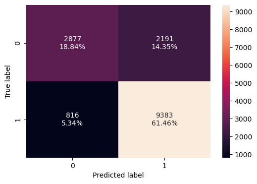

```python
# Confusion matrix
confusion_matrix_sklearn(tuned_rf, X_train, y_train)

# Metrics
tuned_rf_model_train_perf = model_performance_classification_sklearn(tuned_rf, X_train, y_train)
tuned_rf_model_train_perf
```

### Checking model performance on validation set

|  | Accuracy | Recall | Precision | F1 |
| --- | --- | --- | --- | --- |
| 0 | 0.744794 | 0.879447 | 0.770876 | 0.82159 |

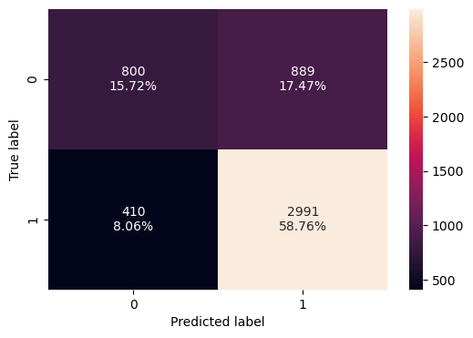

```python
# Validation set
confusion_matrix_sklearn(tuned_rf, X_val, y_val)
tuned_rf_model_val_perf = model_performance_classification_sklearn(tuned_rf, X_val, y_val)
tuned_rf_model_val_perf
```

### Tuning Decision Trees model with original Data

```python
# Define the model
dt_model = DecisionTreeClassifier(random_state=1)

# Define your custom parameter grid
param_grid = {
    'max_depth': np.arange(2, 6),
    'min_samples_leaf': [1, 4, 7],
    'max_leaf_nodes': [10, 15],
    'min_impurity_decrease': [0.0001, 0.001]
}

# Define F1 scorer
f1_scorer = metrics.make_scorer(metrics.f1_score)

# Set up GridSearchCV
grid_search = GridSearchCV(
    estimator=dt_model,
    param_grid=param_grid,
    scoring=f1_scorer,
    cv=5,
    n_jobs=-1
)

# Fit to the training data
grid_search.fit(X_train, y_train)

# Print best parameters and score
print("Best parameters:", grid_search.best_params_)
print("Best cross-validation F1 score: {:.4f}".format(grid_search.best_score_))

# Refit the model using best parameters
tuned_decision_tree = grid_search.best_estimator_
tuned_decision_tree.fit(X_train, y_train)
```

```
Best parameters: {'max_depth': 5, 'max_leaf_nodes': 15, 'min_impurity_decrease': 0.0001, 'min_samples_leaf': 1}
Best cross-validation F1 score: 0.8222
```

```
DecisionTreeClassifier(max_depth=5, max_leaf_nodes=15,
                       min_impurity_decrease=0.0001, random_state=1)
```

```python
tuned_decision_tree = DecisionTreeClassifier(
    max_depth=5,
    max_leaf_nodes=15,
    min_impurity_decrease=0.0001,
    min_samples_leaf=1,
    random_state=1
)
tuned_decision_tree.fit(X_train, y_train)
```

```
DecisionTreeClassifier(max_depth=5, max_leaf_nodes=15,
                       min_impurity_decrease=0.0001, random_state=1)
```

#### Checking model performance on training set

```
Train Performance:
   Accuracy    Recall  Precision        F1
0  0.737145  0.915874   0.747519  0.823177
```

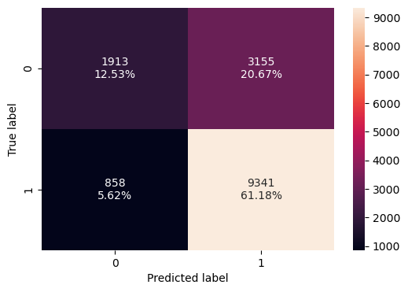

```python
confusion_matrix_sklearn(tuned_decision_tree, X_train, y_train)
dt_train_perf = model_performance_classification_sklearn(tuned_decision_tree, X_train, y_train)
print("Train Performance:")
print(dt_train_perf)
```

#### Checking model performance on validation set

```
Validation Performance:
   Accuracy    Recall  Precision        F1
0  0.733399  0.910615   0.746265  0.820289
```

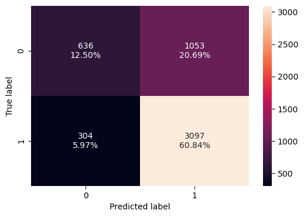

```python
confusion_matrix_sklearn(tuned_decision_tree, X_val, y_val)
dt_val_perf = model_performance_classification_sklearn(tuned_decision_tree, X_val, y_val)
print("\nValidation Performance:")
print(dt_val_perf)
```

### Tuning XGBoost model with original Data

```python
%%time
# Choose the type of classifier
tuned_xgb = XGBClassifier(random_state=1, eval_metric="logloss")

# Grid of parameters to choose from
parameters = {
    "n_estimators": np.arange(50, 110, 25),
    "scale_pos_weight": [1, 2, 5],
    "subsample": [0.9, 1],
    "learning_rate": [0.01, 0.1, 0.05],
    "gamma": [1, 3]
}

# Type of scoring used to compare parameter combinations
acc_scorer = metrics.make_scorer(metrics.f1_score)

# Run the grid search
grid_obj = GridSearchCV(
    estimator=tuned_xgb,
    param_grid=parameters,
    scoring=acc_scorer,
    cv=5,
    n_jobs=-1
)

# Fit the grid search to the training data
grid_obj = grid_obj.fit(X_train, y_train)

# Set the classifier to the best combination of parameters
tuned_xgb = grid_obj.best_estimator_

# Fit the best algorithm to the training data
tuned_xgb.fit(X_train, y_train)
```

```
CPU times: total: 7.95 s
Wall time: 1min 14s
```

```
XGBClassifier(base_score=None, booster=None, callbacks=None,
              colsample_bylevel=None, colsample_bynode=None,
              colsample_bytree=None, device=None, early_stopping_rounds=None,
              enable_categorical=False, eval_metric='logloss',
              feature_types=None, feature_weights=None, gamma=3,
              grow_policy=None, importance_type=None,
              interaction_constraints=None, learning_rate=0.05, max_bin=None,
              max_cat_threshold=None, max_cat_to_onehot=None,
              max_delta_step=None, max_depth=None, max_leaves=None,
              min_child_weight=None, missing=nan, monotone_constraints=None,
              multi_strategy=None, n_estimators=50, n_jobs=None,
              num_parallel_tree=None, ...)
```

```python
# Define the tuned XGBoost model
xgb_tuned_model = XGBClassifier(
    random_state=1,
    eval_metric='logloss',
    n_estimators=50,
    learning_rate=0.05,
    gamma=3
)

# Fit the model on training data
xgb_tuned_model.fit(X_train, y_train)
```

```
XGBClassifier(base_score=None, booster=None, callbacks=None,
              colsample_bylevel=None, colsample_bynode=None,
              colsample_bytree=None, device=None, early_stopping_rounds=None,
              enable_categorical=False, eval_metric='logloss',
              feature_types=None, feature_weights=None, gamma=3,
              grow_policy=None, importance_type=None,
              interaction_constraints=None, learning_rate=0.05, max_bin=None,
              max_cat_threshold=None, max_cat_to_onehot=None,
              max_delta_step=None, max_depth=None, max_leaves=None,
              min_child_weight=None, missing=nan, monotone_constraints=None,
              multi_strategy=None, n_estimators=50, n_jobs=None,
              num_parallel_tree=None, ...)
```

### Checking model performance on training set

|  | Accuracy | Recall | Precision | F1 |
| --- | --- | --- | --- | --- |
| 0 | 0.758171 | 0.896657 | 0.776118 | 0.832044 |

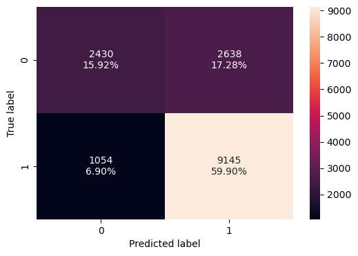

```python
confusion_matrix_sklearn(xgb_tuned_model, X_train, y_train)
xgb_tuned_model_train_perf = model_performance_classification_sklearn(xgb_tuned_model, X_train, y_train)
display(xgb_tuned_model_train_perf)
```

### Checking model performance on validation set

|  | Accuracy | Recall | Precision | F1 |
| --- | --- | --- | --- | --- |
| 0 | 0.747348 | 0.889738 | 0.768606 | 0.824748 |

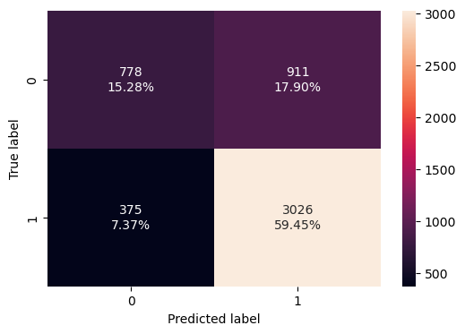

```python
confusion_matrix_sklearn(xgb_tuned_model, X_val, y_val)
xgb_tuned_model_val_perf = model_performance_classification_sklearn(xgb_tuned_model, X_val, y_val)
display(xgb_tuned_model_val_perf)
```

### Tuning LGBM model with original Data

```python
# 1. Define the base model
lgbm_model = LGBMClassifier(random_state=1)

# 2. Define the parameter grid
param_grid = {
    'n_estimators': [50, 75, 100],
    'learning_rate': [0.01, 0.05, 0.1],
    'max_depth': [3, 5, 7],
    'num_leaves': [15, 31, 63],
    'subsample': [0.8, 0.9, 1.0]
}

# 3. Define F1 scorer (or change to 'accuracy', 'roc_auc', etc.)
f1_scorer = metrics.make_scorer(metrics.f1_score)

# 4. Setup GridSearchCV
grid_search = GridSearchCV(
    estimator=lgbm_model,
    param_grid=param_grid,
    scoring=f1_scorer,
    cv=5,
    n_jobs=-1
)

# 5. Fit the model
grid_search.fit(X_train, y_train)

# 6. Output the best parameters and best score
print("Best parameters:", grid_search.best_params_)
print("Best cross-validation F1 score: {:.4f}".format(grid_search.best_score_))
```

```
Best parameters: {'learning_rate': 0.01, 'max_depth': 7, 'n_estimators': 100, 'num_leaves': 15, 'subsample': 0.8}
Best cross-validation F1 score: 0.8252
```

```python
# Refit the model with best parameters
tuned_lgbm = grid_search.best_estimator_
tuned_lgbm.fit(X_train, y_train)
```

```
LGBMClassifier(learning_rate=0.01, max_depth=7, num_leaves=15, random_state=1,
               subsample=0.8)
```

#### Checking model performance on training set

|  | Accuracy | Recall | Precision | F1 |
| --- | --- | --- | --- | --- |
| 0 | 0.743499 | 0.919502 | 0.751864 | 0.827276 |

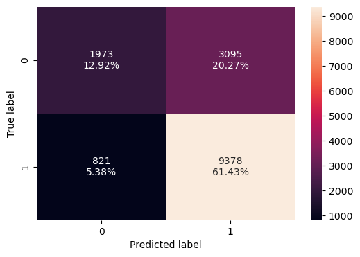

```python
# Confusion Matrix
confusion_matrix_sklearn(tuned_lgbm, X_train, y_train)

# Classification report
lgbm_train_perf = model_performance_classification_sklearn(
    tuned_lgbm, X_train, y_train
)
lgbm_train_perf
```

#### Checking model performance on validation set

|  | Accuracy | Recall | Precision | F1 |
| --- | --- | --- | --- | --- |
| 0 | 0.740864 | 0.914437 | 0.751571 | 0.825043 |

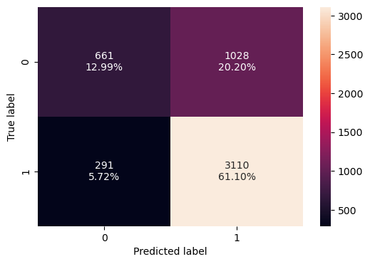

```python
# Confusion Matrix
confusion_matrix_sklearn(tuned_lgbm, X_val, y_val)

# Classification report
lgbm_val_perf = model_performance_classification_sklearn(
    tuned_lgbm, X_val, y_val
)
lgbm_val_perf
```

### Tuning Catboost model with original Data

```python
%%time

# Define the CatBoost model
Model = CatBoostClassifier(random_state=1, verbose=0)

# Parameter grid for CatBoost
param_grid = {
    "iterations": np.arange(50, 150, 25),
    "learning_rate": [0.01, 0.05, 0.1],
    "depth": [4, 6, 8, 10],
    "l2_leaf_reg": [1, 3, 5, 7, 9],
    "border_count": [32, 64, 128]
}

# F1 scorer
scorer = metrics.make_scorer(metrics.f1_score)

# RandomizedSearchCV
randomized_cv = RandomizedSearchCV(
    estimator=Model,
    param_distributions=param_grid,
    n_iter=50,
    scoring=scorer,
    cv=5,
    random_state=1,
    n_jobs=-1
)

# Fit the model
randomized_cv.fit(X_train, y_train)

# Print best parameters and F1 score
print("Best parameters are {} with CV score={:.4f}:".format(randomized_cv.best_params_, randomized_cv.best_score_))
```

```
Best parameters are {'learning_rate': 0.05, 'l2_leaf_reg': 1, 'iterations': 50, 'depth': 6, 'border_count': 32} with CV score=0.8249:
CPU times: total: 7.86 s
Wall time: 4min 9s
```

```python
# Create and train CatBoost model with best parameters from tuning
tuned_catboost = CatBoostClassifier(
    iterations=50,            # Number of boosting iterations
    learning_rate=0.05,        # Step size shrinkage
    l2_leaf_reg=1,            # L2 regularization coefficient
    depth=6,                  # Depth of the tree
    border_count=32,         # Number of splits for numerical features
    subsample=0.9,            # Subsample ratio for stochastic boosting
    random_state=1,           # For reproducibility
    verbose=0                 # Suppress training output
)

# Fit the model
tuned_catboost.fit(X_train, y_train)
```

```
<catboost.core.CatBoostClassifier at 0x15a2dd617f0>
```

```python
catboost_train_perf = model_performance_classification_sklearn(
    tuned_catboost, X_train, y_train
)
print("CatBoost Training Performance:")
print(catboost_train_perf)
```

```
CatBoost Training Performance:
   Accuracy    Recall  Precision        F1
0  0.751032  0.902147   0.766495  0.828807
```

```python
catboost_val_perf = model_performance_classification_sklearn(
    tuned_catboost, X_val, y_val
)
print("\nCatBoost Validation Performance:")
print(catboost_val_perf)
```

```
CatBoost Validation Performance:
   Accuracy    Recall  Precision        F1
0  0.744401  0.896207   0.762763  0.824118
```